# Further Comparison of Workflows: LCIA QSAR Project

**Date:** April 20, 2023

This notebook builds on the comparison between our original draft workflow with that of Nicolo Aurisano.

First, I refactored our workflow in several ways:

- Replaced the original metals filter with a less strict filter that excludes chemicals only if they lack a "QSAR-ready" SMILES
- Updated the features to include the experimental LD50s (median) instead of the TEST predictions.
- Using a different transformer function to reduce skew during feature preprocessing. In particular, I noticed that my original Log10Transformer can be problematic for skewed features with a small proportion of negative values in the dataset. The algorithm identifies which columns to transform based on the *training* set to avoid "data leakage." There were some cases in which some negative values were sampled in the *test* set but not the training set, which led to errors in the log-transformation. As an alternative, this notebook uses the Yeo-Johnson power transform which accepts negative values: https://scikit-learn.org/stable/modules/generated/sklearn.preprocessing.PowerTransformer.html#sklearn.preprocessing.PowerTransformer

This notebook compares the following workflows:

1. Original draft workflow with updates described above
1. Alternative workflow that uses only chemicals with complete data, while omitting both feature selection and imputation

```python
import pandas as pd
import numpy as np
from os import path
import matplotlib.pyplot as plt

from sklearn.model_selection import RepeatedKFold
from sklearn.impute import SimpleImputer
from sklearn.preprocessing import PowerTransformer
from sklearn.tree import DecisionTreeRegressor
from sklearn.linear_model import (
    Ridge,
    Lasso
)
from sklearn.ensemble import (
    RandomForestRegressor,
    GradientBoostingRegressor
)
from xgboost import XGBRegressor
from sklearn.ensemble import VotingRegressor
from sklearn.pipeline import Pipeline
from sklearn import metrics
from sklearn.inspection import permutation_importance

import parse
# Enable modules to be imported from the parent directory.
import sys
sys.path.append('..')
from common.transform import (
    BasicFeatureSelector,
    SelectiveScaler
)
from common import (
    input_output,
    features,
    learn,
    plot
)
```

## Load the data

Combine the OPERA-TEST predictions with the experimental LD50s as features. Use the log10(POD) for general effects as the target variable.

```python
path_components_mapper = {
    'features' : [
        ('Features', 'OPERA-TEST-predictions.csv'),
        ('Features', 'experimental-LD50s.csv')
    ],
    'targets' : [
        ('Targets', 'log10-POD-general-effects.csv')
    ]
}

csv_kwargs = {
    'index_col' : 0
}

data = input_output.combine_csv_files(
    path_components_mapper,
    **csv_kwargs)

data
```

| DTXSID | features AVERAGE_MASS | features 48HR_DAPHNIA_LC50_MOL/L_TEST_PRED | features DENSITY_G/CM^3_TEST_PRED | features DEVTOX_TEST_PRED | features 96HR_FATHEAD_MINNOW_MOL/L_TEST_PRED | features FLASH_POINT_DEGC_TEST_PRED | features AMES_MUTAGENICITY_TEST_PRED | features ORAL_RAT_LD50_MOL/KG_TEST_PRED | features SURFACE_TENSION_DYN/CM_TEST_PRED | features THERMAL_CONDUCTIVITY_MW/(M*K)_TEST_PRED | features ... | features OCTANOL_AIR_PARTITION_COEFF_KOA_OPERA_PRED | features SOIL_ADSORPTION_COEFFICIENT_KOC_L/KG_OPERA_PRED | features OCTANOL_WATER_PARTITION_P_OPERA_PRED | features MELTING_POINT_DEGC_OPERA_PRED | features OPERA_PKAA_OPERA_PRED | features OPERA_PKAB_OPERA_PRED | features VAPOR_PRESSURE_MMHG_OPERA_PRED | features WATER_SOLUBILITY_MOL/L_OPERA_PRED | features median_LD50 | targets log10_POD_[mg/kg-d] |
| --- | --- | --- | --- | --- | --- | --- | --- | --- | --- | --- | --- | --- | --- | --- | --- | --- | --- | --- | --- | --- | --- |
| DTXSID5020281 | 157.550 | 0.000108 | 1.372 | 0.323 | 0.000057 | 109.227 | 0.966 | 0.007079 | NaN | 137.950 | ... | 2.124320e+04 | 507.6930 | 246.342872 | 82.9942 | NaN | NaN | 2.203470e-02 | 0.001318 | 138.120754 | -1.098677 |
| DTXSID8020961 | 138.126 | 0.000065 | 1.309 | 0.250 | 0.000439 | 141.229 | 0.642 | 0.009141 | NaN | 162.043 | ... | 3.734737e+06 | 75.9962 | 24.436556 | 145.5400 | NaN | 1.03 | 3.265100e-06 | 0.004816 | 126.969502 | -0.231734 |
| DTXSID7030698 | 972.846 | NaN | 2.278 | NaN | NaN | 458.744 | 0.056 | NaN | NaN | NaN | ... | 4.358329e+09 | 44.0390 | 0.035571 | 201.2070 | NaN | NaN | 2.063360e-09 | 0.389351 | 1728.603923 | 3.472003 |
| DTXSID2026652 | 162.276 | 0.000007 | 0.846 | 0.724 | 0.000018 | 71.527 | NaN | 0.029444 | 28.625 | 121.380 | ... | 1.520407e+05 | 2084.2800 | 18201.618188 | -45.5895 | NaN | NaN | 2.476330e-01 | 0.000007 | 782.276836 | 1.042817 |
| DTXSID6026080 | 166.132 | 0.000640 | 1.482 | 0.405 | 0.000156 | 204.940 | 0.358 | 0.023550 | NaN | NaN | ... | 6.909872e+07 | 30.6322 | 96.821097 | 284.7150 | NaN | NaN | 9.148410e-06 | 0.000093 | 1222.307556 | 1.842616 |
| ... | ... | ... | ... | ... | ... | ... | ... | ... | ... | ... | ... | ... | ... | ... | ... | ... | ... | ... | ... | ... | ... |
| DTXSID3026645 | 134.222 | 0.000025 | 0.868 | 0.668 | 0.000082 | 54.867 | NaN | 0.023281 | 28.026 | 123.106 | ... | 2.038497e+04 | 1947.7600 | 12763.800280 | -67.9752 | NaN | NaN | 3.578520e-01 | 0.000202 | 953.086430 | 1.871706 |
| DTXSID0029133 | 136.150 | 0.000092 | 1.176 | 0.427 | 0.000261 | 102.496 | 0.105 | 0.007798 | 40.167 | 151.682 | ... | 6.034621e+07 | 53.6562 | 22.465185 | 109.4490 | 7.9 | NaN | 3.236800e-04 | 0.073160 | 547.593785 | 1.215825 |
| DTXSID0021832 | 135.210 | 0.000043 | 0.930 | 0.580 | 0.000328 | 73.437 | 0.375 | 0.004457 | 32.059 | 136.205 | ... | 7.259054e+04 | 79.6007 | 644.184098 | -44.2648 | NaN | 5.56 | 1.789000e-01 | 0.005007 | 239.572281 | 0.799742 |
| DTXSID6020303 | 158.070 | NaN | NaN | 0.793 | NaN | NaN | 0.218 | NaN | NaN | NaN | ... | 1.557866e+03 | 1452.1500 | 0.000159 | 174.9060 | NaN | NaN | 8.103410e-08 | 5.563510 | 88.000079 | 0.581300 |
| DTXSID5023792 | 137.138 | 0.000104 | 1.200 | 0.435 | 0.000192 | 102.856 | 0.609 | 0.008851 | NaN | 141.028 | ... | 3.515443e+04 | 80.1488 | 234.801031 | 30.7996 | NaN | NaN | 1.591180e-02 | 0.003242 | 524.125480 | 0.957466 |

1406 rows × 28 columns

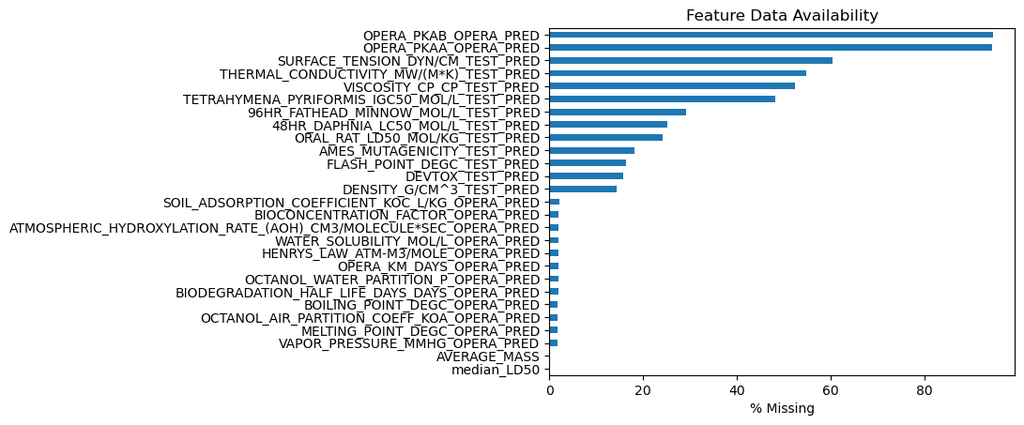

```python
fig, ax = plt.subplots()

percents_missing = (data['features'].isna().sum() / len(data) * 100)

_ = percents_missing.sort_values().plot.barh(ax=ax)

ax.set_title('Feature Data Availability')
ax.set_xlabel('% Missing')
```

### Drop some features

- TEST-predicted LD50s, because we are using the experimental LD50s
- OPERA-predicted pK values, because we do not have a large sample of ionizing chemicals

```python
columns_to_drop = [
    ('features', 'ORAL_RAT_LD50_MOL/KG_TEST_PRED'),
    ('features', 'OPERA_PKAA_OPERA_PRED'),
    ('features', 'OPERA_PKAB_OPERA_PRED')
]

data = data.drop(columns_to_drop, axis=1, errors='ignore')
```

### Instantiate objects for feature preprocessing

```python
selector = (
    BasicFeatureSelector(
        thres_missing=0.20,  # threshold proportion missing
        thres_corr=0.9,  # threshold correlation coefficient
        method_corr='pearson')  # method
)

transformer = PowerTransformer(method='yeo-johnson')

imputer = (
    SimpleImputer(strategy='median')
)

scaler = (
    SelectiveScaler(
        measure='median')
)
```

### Instantiate the estimators

Use the same estimators as before with the following additions:

- `Decision Tree`: Simple and interpretable
- `Meta-Estimator`: Aggregates the predictions of the Ridge, Random Forest, and Gradient Boosting Regressor. For simplicity, the arithmetic mean is used for the aggregation.

```python
# Initialize a container for each workflow.
cv_results_for_workflow = {}

# Use the same rng across estimators for comparability.
rng = np.random.RandomState(seed=0)

estimators = {
    'Tree' : DecisionTreeRegressor(random_state=rng),
    'Ridge' : Ridge(random_state=rng),
    'Lasso' : Lasso(random_state=rng),
    'Random_Forest' : RandomForestRegressor(random_state=rng, n_jobs=-1),
    'Gradient_Boost' : GradientBoostingRegressor(random_state=rng),
    'XGBoost' : XGBRegressor(random_state=rng, n_jobs=-1)
}

estimators_for_ensemble_keys = [
    'Ridge',
    'Random_Forest',
    'Gradient_Boost'
]
meta_estimator = VotingRegressor(
    [(k, v) for k, v in estimators.items()
     if k in estimators_for_ensemble_keys],
    n_jobs=-1
)
estimators['Meta_Estimator'] = meta_estimator
```

## Compare estimators with repeated internal cross-validation

Use 50 randomized repeats of a 5-fold cross-validation. The same data partitions are used for each estimator to enable comparison.

```python
def repeated_kfold_for_estimators(
        estimators, X, y, preprocessing_steps,
        n_splits=5, n_repeats=50, random_state=1):
    '''Helper function which implements a repeated cross-validation for each estimator.
    '''
    # Inialize a container.
    cv_results = {}
    for k, est in estimators.items():

        pipe = Pipeline(steps=preprocessing_steps + [('estimator', est)])

        cv_results[k] = learn.repeated_kfold(
            pipe,
            X,
            y,
            learn.regression_metrics,
            n_splits=n_splits,
            n_repeats=n_repeats,
            random_state=random_state
        )

    return pd.concat(cv_results, axis=1)
```

### Original workflow with updates described above

```python
X = data['features']
y = data['targets']

X.shape, y.shape
```

```
((1406, 24), (1406, 1))
```

```python
%%time

preprocessing_steps = [
    ('selector', selector),
    ('transformer', transformer),
    ('imputer', imputer),
    ('scaler', scaler),
]

cv_results_for_workflow['original'] = repeated_kfold_for_estimators(
    estimators,
    X,
    y,
    preprocessing_steps
)
```

```
CPU times: total: 32min 27s
Wall time: 11min 7s
```

```python
model_scores.describe().drop('count').sort_values(by='mean', axis=1).round(2)
```

|  | Lasso | Tree | Ridge | XGBoost | Gradient_Boost | Meta_Estimator | Random_Forest |
| --- | --- | --- | --- | --- | --- | --- | --- |
| mean | 0.00 | 0.03 | 0.38 | 0.45 | 0.48 | 0.49 | 0.50 |
| std | 0.01 | 0.13 | 0.05 | 0.05 | 0.04 | 0.04 | 0.04 |
| min | -0.05 | -0.41 | 0.21 | 0.25 | 0.33 | 0.35 | 0.35 |
| 25% | -0.00 | -0.05 | 0.35 | 0.42 | 0.45 | 0.46 | 0.47 |
| 50% | 0.00 | 0.04 | 0.38 | 0.45 | 0.48 | 0.49 | 0.50 |
| 75% | 0.01 | 0.12 | 0.41 | 0.48 | 0.51 | 0.52 | 0.53 |
| max | 0.02 | 0.32 | 0.48 | 0.57 | 0.58 | 0.58 | 0.61 |

#### Observations

- Lasso still shows poor performance with its default hyperparameters
- Decision Tree has high variance and low performance - sensitive to the training data
- Meta-Estimator performs about as well as the Random Forest

### Alternative workflow: Chemicals with complete data

```python
not_any_missing = data['features'].notna().all(axis=1)
X = data['features'].loc[not_any_missing]
y = data['targets'].loc[not_any_missing]

X.shape, y.shape
```

```
((387, 24), (387, 1))
```

```python
%%time

preprocessing_steps = [
    ('transformer', transformer),
    ('imputer', imputer),
    ('scaler', scaler),
]

cv_results_for_workflow['alternative'] = repeated_kfold_for_estimators(
    estimators,
    X,
    y,
    preprocessing_steps
)
```

```
CPU times: total: 13min 34s
Wall time: 5min 8s
```

```python
model_scores.describe().drop('count').sort_values(by='mean', axis=1).round(2)
```

|  | Tree | Lasso | XGBoost | Gradient_Boost | Ridge | Random_Forest | Meta_Estimator |
| --- | --- | --- | --- | --- | --- | --- | --- |
| mean | -0.34 | -0.03 | 0.26 | 0.29 | 0.32 | 0.33 | 0.36 |
| std | 0.26 | 0.03 | 0.12 | 0.11 | 0.09 | 0.10 | 0.08 |
| min | -1.31 | -0.23 | -0.11 | -0.12 | 0.05 | -0.06 | 0.05 |
| 25% | -0.51 | -0.03 | 0.17 | 0.23 | 0.27 | 0.27 | 0.31 |
| 50% | -0.32 | -0.02 | 0.27 | 0.30 | 0.33 | 0.34 | 0.37 |
| 75% | -0.13 | -0.01 | 0.35 | 0.36 | 0.39 | 0.40 | 0.42 |
| max | 0.17 | 0.01 | 0.51 | 0.55 | 0.51 | 0.56 | 0.56 |

#### Observations

- Few chemicals have "complete" data and hence performance diminished
- In this case, Meta-Estimator may have performed best

## Permutation feature importances (repeated)

Implement the same repeated 5-fold cross-validation with the addition of an internal loop which computes permutation feature importance scores on the test data. This algorithm is relatively expensive, so I restricted the number of permutations to 5 and returned the mean scores across permutations. The description statistics that follow are therefore computed on these means values.

### Note of caution

I did not use these importance scores for any feature selection because I was worried about optimistically biasing the model ("data leakage") without using a nested cross-validation strategy.

```python
def repeated_permutation_importance(
        estimator, X, y, scoring=None, n_splits=5, n_cv_repeats=50,
        n_permutation_repeats=5, random_state=1):
    '''Compute permutation feature importances with repeated cross-validation.
    '''
    if scoring is None:
        scoring = 'r2'

    if hasattr(X, 'columns'):
        columns = X.columns
    else:
        columns = pd.RangeIndex(X.shape[-1])

    X, y = learn.ensure_numpy_ndarrays(X, y)

    rkf = RepeatedKFold(
        n_splits=n_splits,
        n_repeats=n_cv_repeats,
        random_state=random_state)

    # Initialize a container.
    permutation_results = []
    for train_ix, test_ix in rkf.split(X):
        X_train, X_test = X[train_ix, :], X[test_ix, :]
        y_train, y_test = y[train_ix], y[test_ix]
        estimator.fit(X_train, y_train)

        results = permutation_importance(
            estimator,
            X_test,
            y_test,
            scoring=scoring,
            n_repeats=n_permutation_repeats,
            random_state=random_state,
            n_jobs=-1)
        permutation_results.append(results['importances_mean'])

    return pd.DataFrame(permutation_results, columns=columns)
```

```python
%%time

estimator = Pipeline(
    steps=preprocessing_steps + [('estimator', estimators['Meta_Estimator'])])

importances = repeated_permutation_importance(estimator, X, y)
```

```
CPU times: total: 5min 23s
Wall time: 7min 11s
```

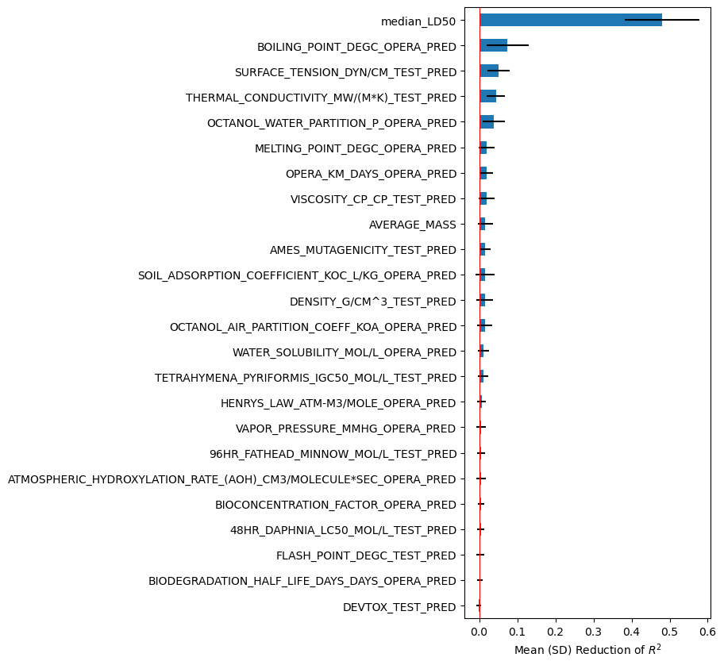

```python
figsize = (4., 10.)
xlabel = 'Mean (SD) Reduction of $R^2$'
ylabel = None

means = importances.mean().sort_values()
stds = importances.std().loc[means.index]

fig, ax = plt.subplots(figsize=figsize)

means.plot.barh(
    ax=ax,
    xerr=stds)

ax.set_xlabel(xlabel)
ax.set_ylabel(ylabel)

ylim = ax.get_ylim()
ax.vlines(0., *ylim, color='red', linewidth=0.75)

fig.tight_layout()
```